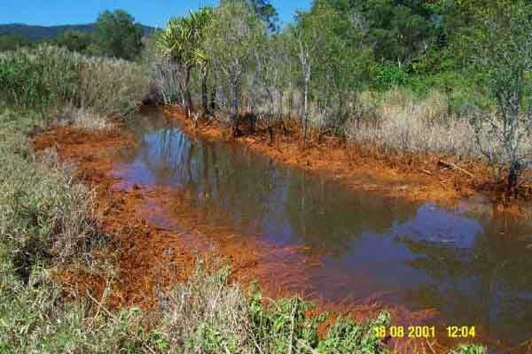

A team of earth scientists was mapping the distribution of acid sulphate soils near estuaries in northern NSW. They were interested in whether remediation works had affected the pH of soils. They obtained the following pH data from 8 sites that had remediation works, and 8 sites that had not been manipulated:

Remediated sites Un-manipulated sites 6.7 6.6 7.1 6.7 6.9 6.8 7.0 7.2 6.6 7.0 6.6 6.9 7.2 7.1 7.5 6.8

```r
acidsoil = read.csv(file = "Acidsoil.csv", header = T)
```

Firstly, visualise the differences in pH between the remediated and unremediated sites.

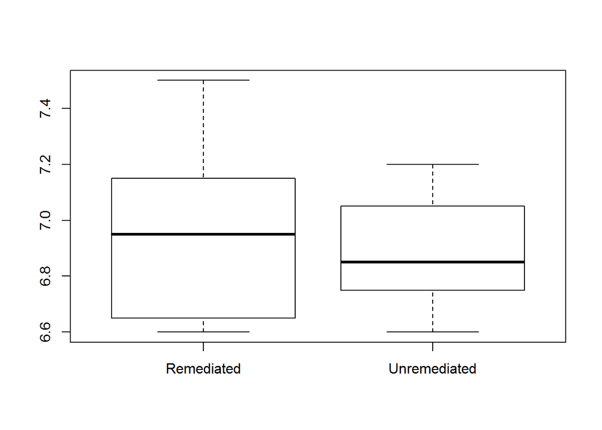

```r
boxplot(pH~Site, data = acidsoil)
```

**A)** What statistical test could you use to detect whether the remediation efforts had altered the pH of soil?

```r
# {1:MULTICHOICE:=Two sample t test~Goodness of fit test~Paired t test~Contingency table}
```

**B)** Check the assumptions of the test. Should you transform the data?

```r
# {1:MULTICHOICE:=Yes, the data have a skewed distribution~No, the data are normally distributed and variances are equal~No, the data were collected carefully}
```

**C)** Conduct the test, and give the value of the test statistic and P value.

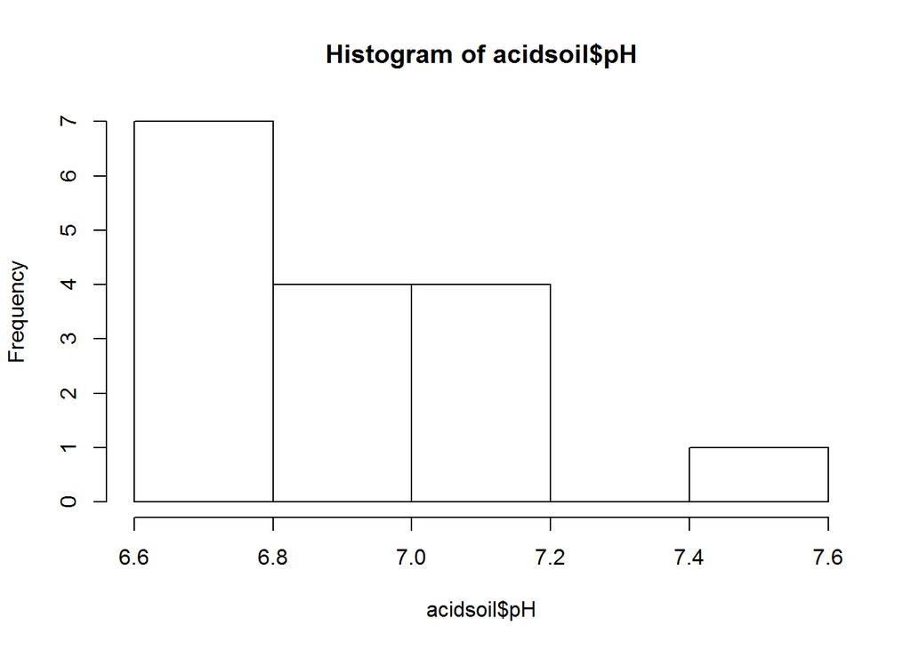

```r
hist(acidsoil$pH)
```

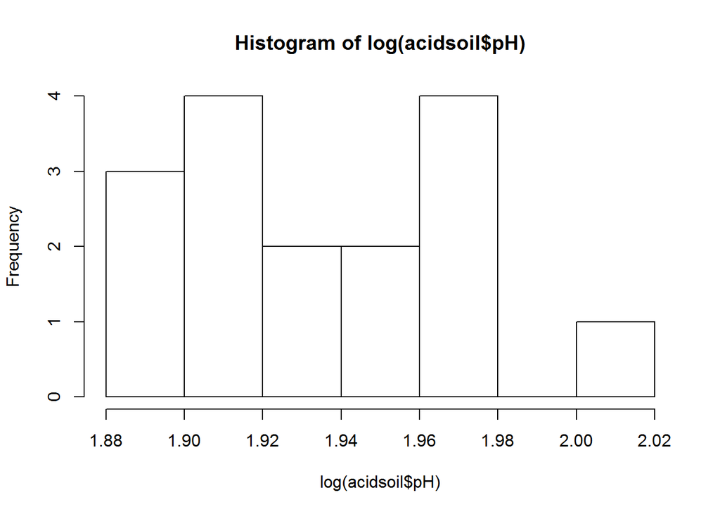

```r
hist(log(acidsoil$pH))
```

```r
t.test(pH~Site, data = acidsoil, var.equal=T)
```

```
##
##  Two Sample t-test
##
## data:  pH by Site
## t = 0.4704, df = 14, p-value = 0.6453
## alternative hypothesis: true difference in means is not equal to 0
## 95 percent confidence interval:
##  -0.2225  0.3475
## sample estimates:
##   mean in group Remediated mean in group Unremediated
##                      6.950                      6.888
```

```r
t.test(log(pH)~Site, data = acidsoil, var.equal=T)
```

```
##
##  Two Sample t-test
##
## data:  log(pH) by Site
## t = 0.4467, df = 14, p-value = 0.6619
## alternative hypothesis: true difference in means is not equal to 0
## 95 percent confidence interval:
##  -0.03237  0.04940
## sample estimates:
##   mean in group Remediated mean in group Unremediated
##                      1.938                      1.929
```

**D)* Is there any evidence that the remediation efforts were sucessful?

```r
#{1:MULTICHOICE:=No~Yes}
```

**E)** The sites belonged to a few different land use categories (farmland, bushland and heathland). Suggest a new sampling design, or new analyses, that would ensure that the data were not confounded by possible differences in soil pH among the land use categories?